# Causal Data Science - Airbnb

### Set working directory

```r
setwd('E:/SPRING 2020/CS 7290/project')
```

# 1. Create the DAG using bnlearn

```r
# Define the nodes of the dag

dag <- empty.graph(nodes = c("bathrooms","cost_property","bedrooms","apartment_age","amenities_score",
                             "cleaning_fee","room_type","price","review_scores_rating","pets","proximity_score",
                             "zipcode","ROI"))

# Set the arcs of the dag

arc.set <- matrix(c("bathrooms" , "cost_property",
                    "bedrooms" , "cost_property",
                    "price" , "ROI",
                    "amenities_score" , "review_scores_rating",
                    "apartment_age" , "amenities_score",
                    "apartment_age" , "cost_property",
                    "cleaning_fee" , "price",
                    "cost_property" , "ROI",
                    "proximity_score" , "price",
                    "proximity_score" , "cost_property",
                    "zipcode" , "price",
                    "zipcode" , "cost_property",
                    "zipcode" , "proximity_score",
                    "zipcode" , "review_scores_rating",
                    "zipcode" , "room_type",
                    "pets" , "price",
                    "pets" , "cleaning_fee",
                    "review_scores_rating" , "price",
                    "room_type" , "bathrooms",
                    "room_type" , "bedrooms",
                    "room_type" , "price",
                    "room_type" , "cost_property"),
                  byrow = TRUE, ncol = 2,
                  dimnames = list(NULL, c("from", "to")))

arcs(dag) <- arc.set

# Nodes of the dag

nodes(dag)
```

```
##  [1] "bathrooms"            "cost_property"        "bedrooms"
##  [4] "apartment_age"        "amenities_score"      "cleaning_fee"
##  [7] "room_type"            "price"                "review_scores_rating"
## [10] "pets"                 "proximity_score"      "zipcode"
## [13] "ROI"
```

```r
# Factorization of dag using modelstring function from bnlearn

modelstring(dag)
```

[output not shown]

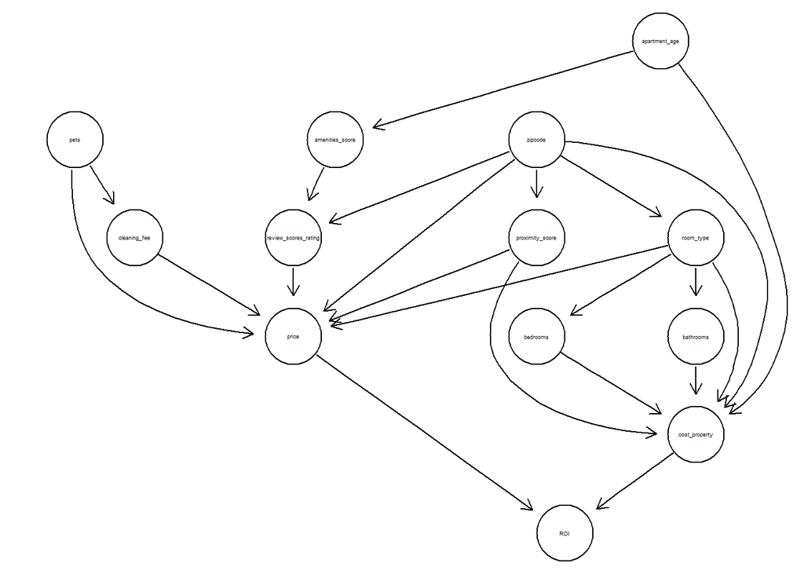

```r
# Plotting the dag using graphviz from Rgraphviz package

graphviz.plot(dag)
```

```r
# Fitting the above same dag using dagitty package. This can be helpful in using some the functions like adjustment sets which are not provided in bnlearn

dagitty_dag <- dagitty("dag{bathroom -> cost_property;
  bedroom -> cost_property;
  price -> ROI;
  amenities_score -> review_scores_rating;
  apartment_age -> amenities_score;
  apartment_age -> cost_property;
  cleaning_fee -> price;
  cost_property -> ROI;
  proximity_score -> price;
  proximity_score -> cost_property;
  zipcode -> price;
  zipcode -> cost_property;
  zipcode -> proximity_score;
  zipcode -> review_scores_rating;
  zipcode -> room_type;
  pets -> price;
  pets -> cleaning_fee;
  review_scores_rating -> price;
  room_type -> bathroom;
  room_type -> bedroom;
  room_type -> price;
  room_type -> cost_property}")

# Example of adjustment set

adjustmentSets(dagitty_dag,'proximity_score','ROI', type = 'minimal')
```

```
##  { zipcode }
```

This says that minimal adjustment set for finding causal effect of proximity_score on ROI is {zipcode}. You can also find all the adjustment sets using type = ‘all’.

# 2. Importing the Dataset and discretize the variables

```r
# Read the file

listing_data<- read_csv('listings_final (1).csv')
# Drop the rows with NA values

cdf <- listing_data %>%
  select("bathrooms","cost_property","bedrooms","amenities_score","cleaning_fee","pets","apartment_age",
         "room_type","price","review_scores_rating","proximity_score","zipcode","ROI"
  ) %>%
  drop_na()  %>% filter(cost_property <= 3307840)

# Discretize the variable using 'hatermink' method from bnlearn package

df <- cdf  %>%
  mutate(cost_property= as.numeric(cost_property),
         amenities_score=as.numeric(amenities_score), cleaning_fee=as.numeric(cleaning_fee),
         review_scores_rating=as.numeric(review_scores_rating),zipcode=as.numeric(zipcode),
         ROI=as.numeric(ROI), price=as.numeric(price),apartment_age = as.numeric(apartment_age)) %>%
  select(cost_property,cleaning_fee,amenities_score,cleaning_fee, ROI,review_scores_rating,
         zipcode, price, apartment_age)%>%
  discretize(method = "hartemink", breaks = 3, ibreaks=4)

# Some of the variable where already in discrete form and hence only converting them to factors

df['proximity_score'] <- as.factor(cdf$proximity_score)
df['room_type'] <- as.factor(cdf$room_type)
df['pets'] <- as.factor(cdf$pets)
df['bathrooms'] = as.factor(cdf$bathrooms)

df['bedrooms']= as.factor(cdf$bedrooms)

str(df)
```

```
## 'data.frame':    103 obs. of  13 variables:
##  $ cost_property       : Factor w/ 3 levels "[1.16e+05,4.31e+05]",..: 2 3 3 1 3 3 3 1 3 3 ...
##  $ cleaning_fee        : Factor w/ 3 levels "[0,35]","(35,75]",..: 3 2 1 3 3 3 3 1 2 1 ...
##  $ amenities_score     : Factor w/ 3 levels "[10,26]","(26,42]",..: 2 2 3 2 3 2 2 1 1 2 ...
##  $ ROI                 : Factor w/ 3 levels "(-85.6,2.38]",..: 2 1 1 3 3 1 1 1 2 1 ...
##  $ review_scores_rating: Factor w/ 3 levels "[80,96]","(96,99]",..: 1 2 2 2 2 2 2 2 1 2 ...
##  $ zipcode             : Factor w/ 3 levels "[78701,78703]",..: 1 2 2 3 2 1 3 3 2 1 ...
##  $ price               : Factor w/ 3 levels "[30,85]","(85,149]",..: 3 2 2 3 3 2 2 1 3 1 ...
##  $ apartment_age       : Factor w/ 3 levels "(2009,2012]",..: 1 1 1 2 2 1 1 3 1 2 ...
##  $ proximity_score     : Factor w/ 5 levels "1","2","3","4",..: 5 4 3 2 3 3 3 3 3 5 ...
##  $ room_type           : Factor w/ 2 levels "Entire home/apt",..: 1 1 1 1 1 1 1 2 1 1 ...
##  $ pets                : Factor w/ 2 levels "0","1": 2 2 2 2 2 2 2 2 2 2 ...
##  $ bathrooms           : Factor w/ 8 levels "1","1.5","2",..: 3 1 1 3 1 1 3 1 1 1 ...
##  $ bedrooms            : Factor w/ 6 levels "0","1","2","3",..: 3 1 2 4 3 3 4 2 3 2 ...
```

# 3. Markov Property and Faithfulness Assumption

```r
## Finding all possible combination of x,y,z sets

vars <- nodes(dag)
# vars <- vars[vars != 'apartment_age']
pairs <- combn(x = vars, 2, list)
arg_sets <- list()
for(pair in pairs){
  if('apartment_age' %in% pair) next
  others <- setdiff(vars, pair)
  conditioning_sets <- unlist(lapply(0:4, function(.x) combn(others, .x, list)), recursive = F)
  for(set in conditioning_sets){
    args <- list(x = pair[1], y = pair[2], z = set)
    arg_sets <- c(arg_sets, list(args))
  }
}

d_sep <- bnlearn:::dseparation

# True d-sep statements

d_sep_list <- list()

for(elem in arg_sets){
  is_dsep = d_sep(dag, x=elem$x, y=elem$y, z=elem$z)
  if(is_dsep){
    d_sep_list = list.append(d_sep_list,elem)
  }
}

#True Conditionally independent statements

independent_list <- list()

for(elem in arg_sets){
  test_outcome <- ci.test(elem$x, elem$y, elem$z, df)
  if(test_outcome$p.value > 0.05){
    independent_list = list.append(independent_list,elem)
  }
}

# Markov Property
# which is ratio of number of true dsep statement in dag that are also conditionally independent in dataset to the number of true dsep statements

sum(d_sep_list %in% independent_list)/length(d_sep_list)
```

```
## [1] 0.9864727
```

```r
# Faithfulness Assumption
# which is ratio of number of true CI statement in dataset that are also d separated in dag to the number of true conditionally independent statements

sum(independent_list %in% d_sep_list)/length(independent_list)
```

```
## [1] 0.1851892
```

# 4. Generate CPT table

```r
# Fitting the dataset to the dag and generating the CPT tables

bn_dag <- bn.fit(dag, data = df, method = 'bayes')
```

# 5. Interventions

```r
# Function which calculates causal effect by subtracting second term from first

causal_effect_high_ROI <- function(first,second){
  first_high_roi <- mean(bnlearn::rbn(first, 50000)[,'ROI'] == '(124,531]')
  second_high_roi <- mean(bnlearn::rbn(second, 50000)[,'ROI'] == '(124,531]')
  print(second_high_roi - first_high_roi)
}
```

Now lets answer some of the questions related to ROI. For the next few subsections, we will mutilate (‘do’ operation) the dag to set a variable to specific value and observing causal effect of that on ROI.

### 5.1 Effect of Number of rooms on ROI

```r
med_rooms <- mutilated(bn_dag, evidence = list(bedrooms = '2'))
high_rooms <- mutilated(bn_dag, evidence = list(bedrooms = '5'))

causal_effect_high_ROI(med_rooms,high_rooms)
```

```
## [1] 0.02112
```

Causal effect is positive, which means high_rooms have more magnitude than med_rooms. Therefore house with 5 bedrooms will have more ROI than house with 1 or 2 bedrooms, which is logical as 5 bedrooms would have more rent or daily price as compared to 1 or 2 bedrooms.

### 5.2 Effect of Area(zipcode/neighbourhood) on ROI

```r
A_zipcode <- mutilated(bn_dag, evidence = list(zipcode = '[78701,78703]'))
C_zipcode <- mutilated(bn_dag, evidence = list(zipcode = '(78704,78759]'))

causal_effect_high_ROI(A_zipcode,C_zipcode)
```

```
## [1] -0.05146
```

Causal effect is negative, therefore if your house is in area A then you will have more ROI compared to house in area C. From dataset we see that area A covers East downtown, clarksville etc. while area C covers Northwest Hills, McKinney etc.

Therefore having house in areas like downtown can get you more ROI.

### 5.3 Effect of Amenities on ROI

```r
low_amenities <- mutilated(bn_dag, evidence = list(amenities_score = '[10,26]'))
high_amenities <- mutilated(bn_dag, evidence = list(amenities_score = '(42,73]'))

causal_effect_high_ROI(low_amenities,high_amenities)
```

```
## [1] 0.00482
```

Causal effect is positive so having more amenities will have more ROI compared to less amenities.

Below is the comparison of original and mutilated dag.

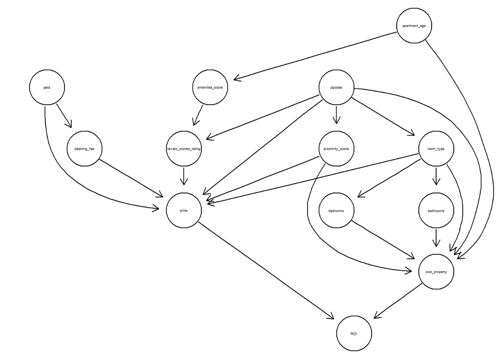

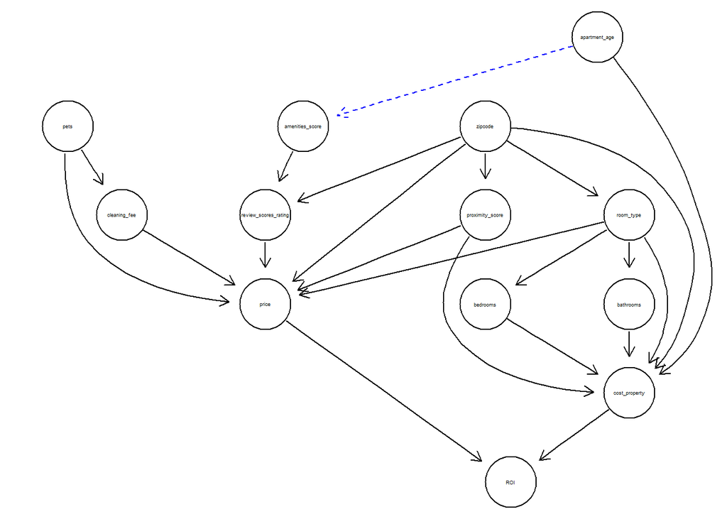

```r
graph =mutilated(dag,list(amenities_score='[10,26]'))

graphviz.compare(dag,graph)
```

### 5.4 Effect of room type on ROI

```r
entire_home <- mutilated(bn_dag, evidence = list(room_type = 'Entire home/apt'))
private_room <- mutilated(bn_dag, evidence = list(room_type = 'Private room'))

causal_effect_high_ROI(entire_home,private_room)
```

```
## [1] -0.06774
```

We get a negative value, which means entire home will have more ROI than private room. Which is again logical as entire home will have more daily price or rent compared to private room.

# 6. Markov Equivalence Class

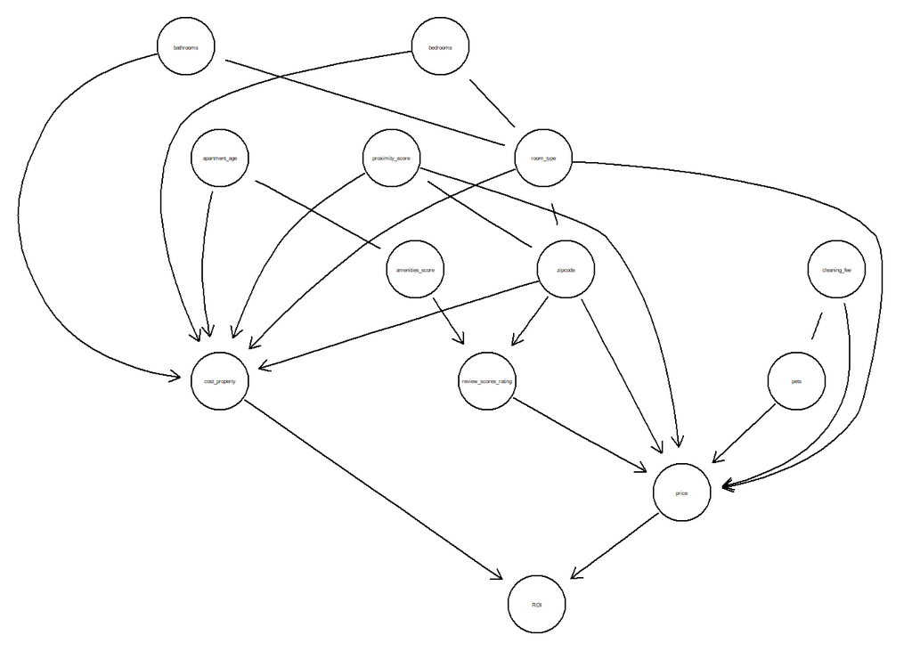

```r
graphviz.plot(cpdag(dag))
```

A Markov equivalence class is a set of DAGs that encode the same set of conditional independencies.